# Homework 2 – Question 2

```r
library(ggplot2)
library(gstat)
load("../data/RainData.RData")   # data.frame `dati` (stations of all years) and `grid`
```

## Weak prompt

I wrote a weak prompt by only giving the instructions and some context about the data. For explanatory analysis, Claude Sonnet fitted a linear regression of the amount of rainfall on the the elevation, the latitude and the longitude, which doesn’t make much sense. It also provided plots of rainfall with respect to latitude and longitude, that were giving interesting information but information that could have been better seen on a map. On top of that it didn’t provide code for a semi-variogram which is essential for analyzing spatial dependence on continuous data. Other than that, the choice of p by cross-validation and the interpolation map are already quite good with the first prompt. With the second prompt Claude is giving indication on how to interpret the results, which is good.

Other than that, the choice of p by cross-validation and the interpolation map are already quite good with the first prompt.

## Good prompt

> I work on a spatial data on rainfall and have measures from several stations in Italy, I will only study the year 1973. Code in R in cells that can be added in a quarto document. Follow these instructions : 1. Run an exploratory data analysis on the rainfall itself. Analyze the relationship between the amount of rain and the elevation. Do basic bivariate analysis (scatter plot with a line corresponding to the linear model, measure of correlation and hypothesis test). Also do a map of the rainfall and a semi-variogram. 2. Using cross-validation, choose the optimal value for p in the IDW estimator, with respect to the MSE . 3. Using the IDW estimator and the optimal p, map the variable of interest on the grid given prediction grid (which is stored in gridXUTM and gridYUTM).

> Preferences: * Use XUTM/YUTM for both stations and grid, in EPSG:32632, with no reprojection. * For each conclusion done let me a way to assess the result

> Data * dati73 is a data.frame with columns totanno (annual rainfall, mm), Quota (elevation, m), Lat10/Lon10 (WGS84 degrees), XUTM/YUTM (metres, EPSG:32632), and anno (year). It originally has 2373 rows (about 190 stations over several years). I have already filtered it to a single year, so it now has one row per station and no duplicated coordinates. * grid is a data.frame with columns XUTM and YUTM. It has 1005 rows and is not a regular grid: every point has unique X and Y values, with irregular spacing. Please plot it as points, not with geom_tile/geom_raster.

## Question 1

**1.1 Distribution of annual rainfall**

```
=== Année : 1973 ===
   Min. 1st Qu.  Median    Mean 3rd Qu.    Max.
  464.9   854.4  1155.1  1241.5  1581.9  2757.6
SD: 464.2054 | CV: 0.3739103
```

```
=== Année : 1974 ===
   Min. 1st Qu.  Median    Mean 3rd Qu.    Max.
  300.6   657.5   907.9   973.2  1229.1  2425.8
SD: 407.1569 | CV: 0.4183669
```

```
=== Année : 1980 ===
   Min. 1st Qu.  Median    Mean 3rd Qu.    Max.
  211.7   717.5  1004.3  1104.7  1429.2  2945.6
SD: 484.7803 | CV: 0.4388356
```

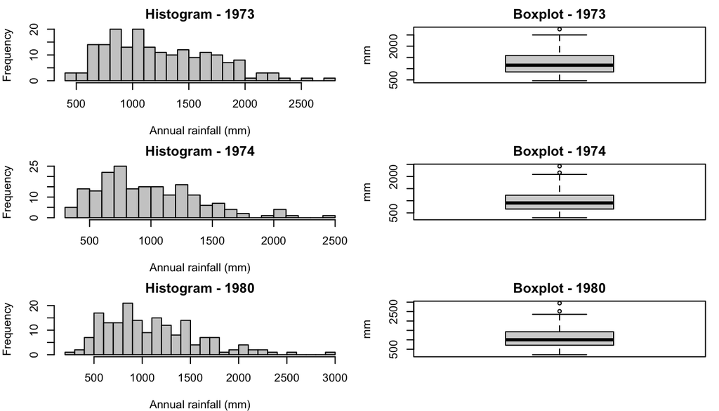

```r
annees <- c(1973, 1974, 1980)

op <- par(mfrow = c(3, 2), mar = c(4, 4, 2, 1))

for (an in annees) {
  dati_an <- dati |>
    dplyr::filter(anno == an)

  cat("\n=== Année :", an, "===\n")
  print(summary(dati_an$totanno))
  cat("SD:", sd(dati_an$totanno, na.rm = TRUE),
      "| CV:", sd(dati_an$totanno, na.rm = TRUE) / mean(dati_an$totanno, na.rm = TRUE), "\n")

  hist(dati_an$totanno,
       breaks = 20,
       col = "grey80",
       main = paste("Histogram -", an),
       xlab = "Annual rainfall (mm)")

  boxplot(dati_an$totanno,
          main = paste("Boxplot -", an),
          ylab = "mm")
}
```

```r
par(op)
```

**1.2 Rainfall vs elevation**

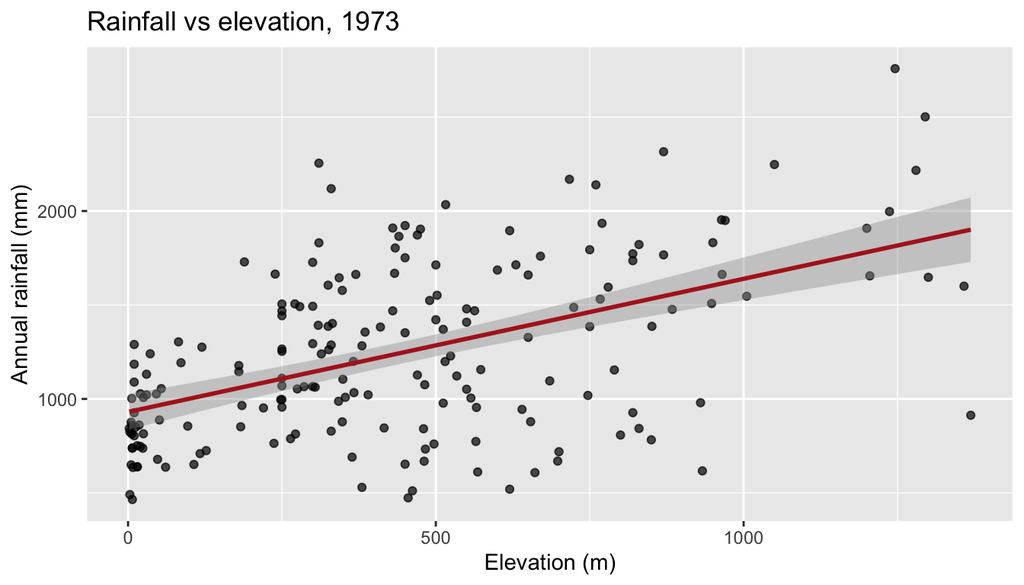

```r
# 1973

data_1973 <- dati |>
  dplyr::filter(anno == 1973)
ggplot(data_1973, aes(Quota, totanno)) +
  geom_point(alpha = 0.7) +
  geom_smooth(method = "lm", se = TRUE, colour = "firebrick") +
  labs(x = "Elevation (m)", y = "Annual rainfall (mm)",
       title = "Rainfall vs elevation, 1973")
```

```r
# correlation measures and tests
ct_p <- cor.test(data_1973$Quota, data_1973$totanno, method = "pearson")
ct_p
```

```
    Pearson's product-moment correlation

data:  data_1973$Quota and data_1973$totanno
t = 8.0518, df = 186, p-value = 9.467e-14
alternative hypothesis: true correlation is not equal to 0
95 percent confidence interval:
 0.3939471 0.6073189
sample estimates:
      cor
0.5083951
```

```r
# simple linear model
fit_lm <- lm(totanno ~ Quota, data = data_1973)
summary(fit_lm)
```

```
Call:
lm(formula = totanno ~ Quota, data = data_1973)

Residuals:
   Min     1Q Median     3Q    Max
-987.5 -285.3  -48.2  261.9 1104.2

Coefficients:
            Estimate Std. Error t value Pr(>|t|)
(Intercept) 930.6927    48.4195  19.221  < 2e-16 ***
Quota         0.7086     0.0880   8.052 9.47e-14 ***
---
Signif. codes:  0 '***' 0.001 '**' 0.01 '*' 0.05 '.' 0.1 ' ' 1

Residual standard error: 400.8 on 186 degrees of freedom
Multiple R-squared:  0.2585,    Adjusted R-squared:  0.2545
F-statistic: 64.83 on 1 and 186 DF,  p-value: 9.467e-14
```

```r
confint(fit_lm)
```

```
                  2.5 %       97.5 %
(Intercept) 835.1706555 1026.2147472
Quota         0.5349559    0.8821721
```

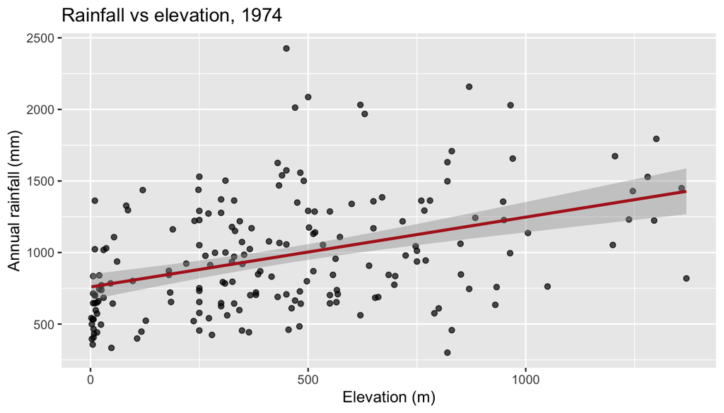

```r
# 1974

data_1974 <- dati |>
  dplyr::filter(anno == 1974)
ggplot(data_1974, aes(Quota, totanno)) +
  geom_point(alpha = 0.7) +
  geom_smooth(method = "lm", se = TRUE, colour = "firebrick") +
  labs(x = "Elevation (m)", y = "Annual rainfall (mm)",
       title = "Rainfall vs elevation, 1974")
```

```r
# correlation measures and tests
ct_p <- cor.test(data_1974$Quota, data_1974$totanno, method = "pearson")
ct_p
```

```
    Pearson's product-moment correlation

data:  data_1974$Quota and data_1974$totanno
t = 5.9394, df = 185, p-value = 1.389e-08
alternative hypothesis: true correlation is not equal to 0
95 percent confidence interval:
 0.2723295 0.5141532
sample estimates:
      cor
0.4001846
```

```r
# simple linear model
fit_lm <- lm(totanno ~ Quota, data = data_1974)
summary(fit_lm)
```

```
Call:
lm(formula = totanno ~ Quota, data = data_1974)

Residuals:
    Min      1Q  Median      3Q     Max
-858.98 -275.73  -77.89  237.88 1446.83

Coefficients:
             Estimate Std. Error t value Pr(>|t|)
(Intercept) 759.38662   45.21671  16.794  < 2e-16 ***
Quota         0.48798    0.08216   5.939 1.39e-08 ***
---
Signif. codes:  0 '***' 0.001 '**' 0.01 '*' 0.05 '.' 0.1 ' ' 1

Residual standard error: 374.1 on 185 degrees of freedom
Multiple R-squared:  0.1601,    Adjusted R-squared:  0.1556
F-statistic: 35.28 on 1 and 185 DF,  p-value: 1.389e-08
```

```r
confint(fit_lm)
```

```
                  2.5 %      97.5 %
(Intercept) 670.1799313 848.5933048
Quota         0.3258902   0.6500699
```

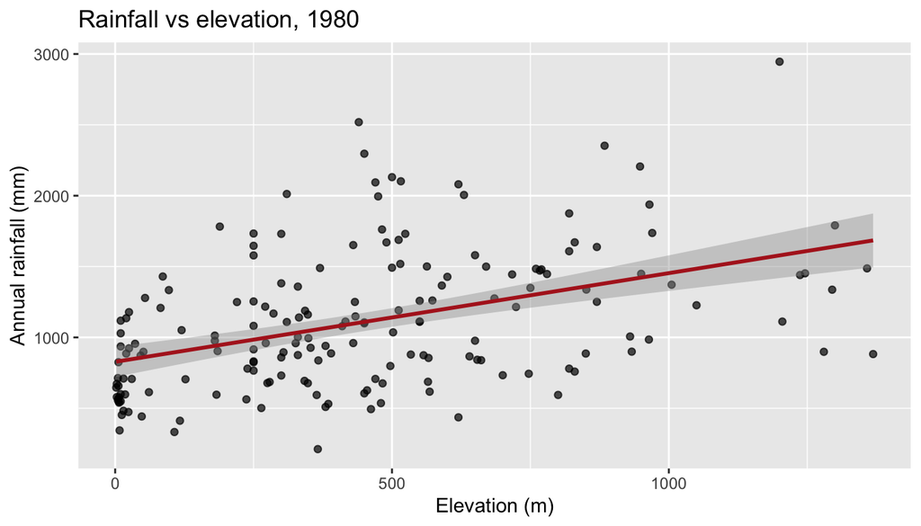

```r
# 1980

data_1980 <- dati |>
  dplyr::filter(anno == 1980)

ggplot(data_1980, aes(Quota, totanno)) +
  geom_point(alpha = 0.7) +
  geom_smooth(method = "lm", se = TRUE, colour = "firebrick") +
  labs(x = "Elevation (m)", y = "Annual rainfall (mm)",
       title = "Rainfall vs elevation, 1980")
```

```r
# correlation measures and tests
ct_p <- cor.test(data_1980$Quota, data_1980$totanno, method = "pearson")
ct_p
```

```
    Pearson's product-moment correlation

data:  data_1980$Quota and data_1980$totanno
t = 6.3966, df = 176, p-value = 1.388e-09
alternative hypothesis: true correlation is not equal to 0
95 percent confidence interval:
 0.3068277 0.5464868
sample estimates:
     cor
0.434312
```

```r
# simple linear model
fit_lm <- lm(totanno ~ Quota, data = data_1980)
summary(fit_lm)
```

```
Call:
lm(formula = totanno ~ Quota, data = data_1980)

Residuals:
    Min      1Q  Median      3Q     Max
-845.16 -302.04  -60.63  245.40 1415.85

Coefficients:
             Estimate Std. Error t value Pr(>|t|)
(Intercept) 827.76758   54.32906  15.236  < 2e-16 ***
Quota         0.62581    0.09784   6.397 1.39e-09 ***
---
Signif. codes:  0 '***' 0.001 '**' 0.01 '*' 0.05 '.' 0.1 ' ' 1

Residual standard error: 437.9 on 176 degrees of freedom
Multiple R-squared:  0.1886,    Adjusted R-squared:  0.184
F-statistic: 40.92 on 1 and 176 DF,  p-value: 1.388e-09
```

```r
confint(fit_lm)
```

```
                 2.5 %      97.5 %
(Intercept) 720.547315 934.9878417
Quota         0.432731   0.8188945
```

Across all three analyzed years (1973, 1974, and 1980), the scatter plots and linear regression models consistently demonstrate a positive linear relationship between elevation (Quota) and annual rainfall (totanno). This reflects the classic orographic effect, where precipitation increases as air masses are forced upward by topography, cooling and condensing moisture along the slopes.

```r
# 1973
fit_lm <- lm(totanno ~ Quota, data = data_1973)
summary(fit_lm)
```

```
Call:
lm(formula = totanno ~ Quota, data = data_1973)

Residuals:
   Min     1Q Median     3Q    Max
-987.5 -285.3  -48.2  261.9 1104.2

Coefficients:
            Estimate Std. Error t value Pr(>|t|)
(Intercept) 930.6927    48.4195  19.221  < 2e-16 ***
Quota         0.7086     0.0880   8.052 9.47e-14 ***
---
Signif. codes:  0 '***' 0.001 '**' 0.01 '*' 0.05 '.' 0.1 ' ' 1

Residual standard error: 400.8 on 186 degrees of freedom
Multiple R-squared:  0.2585,    Adjusted R-squared:  0.2545
F-statistic: 64.83 on 1 and 186 DF,  p-value: 9.467e-14
```

```r
shapiro.test(residuals(fit_lm))
```

```
    Shapiro-Wilk normality test

data:  residuals(fit_lm)
W = 0.99469, p-value = 0.7449
```

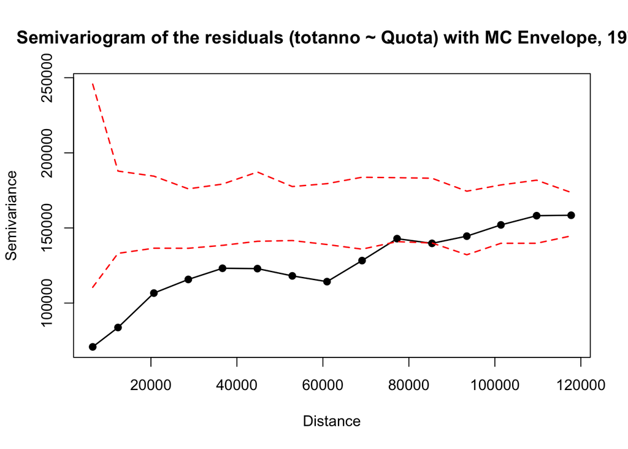

```r
data_1973$res_lm <- residuals(fit_lm)
vr <- variogram(res_lm ~ 1, locations = ~ XUTM + YUTM, data = data_1973)

set.seed(123)
nsim <- 99
cutoff_val <- max(vr$dist) * 1.0001
width_val <- cutoff_val / nrow(vr)

sim_gamma <- replicate(nsim, {
  data_1973$res_perm <- sample(data_1973$res_lm)
  vr_perm <- variogram(res_perm ~ 1, locations = ~ XUTM + YUTM, data = data_1973,
                       cutoff = cutoff_val, width = width_val)
  vr_perm$gamma[1:nrow(vr)]
})

env_low <- apply(sim_gamma, 1, min, na.rm = TRUE)
env_high <- apply(sim_gamma, 1, max, na.rm = TRUE)

plot(vr$dist, vr$gamma,
     ylim = range(c(vr$gamma, env_low, env_high), na.rm = TRUE),
     pch = 19, col = "black",
     xlab = "Distance", ylab = "Semivariance",
     main = "Semivariogram of the residuals (totanno ~ Quota) with MC Envelope, 1973")
lines(vr$dist, vr$gamma, col = "black", lwd = 1.5)
lines(vr$dist, env_low, lty = 2, col = "red", lwd = 1.5)
lines(vr$dist, env_high, lty = 2, col = "red", lwd = 1.5)
```

```r
# 1974

fit_lm <- lm(totanno ~ Quota, data = data_1974)
summary(fit_lm)
```

```
Call:
lm(formula = totanno ~ Quota, data = data_1974)

Residuals:
    Min      1Q  Median      3Q     Max
-858.98 -275.73  -77.89  237.88 1446.83

Coefficients:
             Estimate Std. Error t value Pr(>|t|)
(Intercept) 759.38662   45.21671  16.794  < 2e-16 ***
Quota         0.48798    0.08216   5.939 1.39e-08 ***
---
Signif. codes:  0 '***' 0.001 '**' 0.01 '*' 0.05 '.' 0.1 ' ' 1

Residual standard error: 374.1 on 185 degrees of freedom
Multiple R-squared:  0.1601,    Adjusted R-squared:  0.1556
F-statistic: 35.28 on 1 and 185 DF,  p-value: 1.389e-08
```

```r
shapiro.test(residuals(fit_lm))
```

```
    Shapiro-Wilk normality test

data:  residuals(fit_lm)
W = 0.96153, p-value = 5.388e-05
```

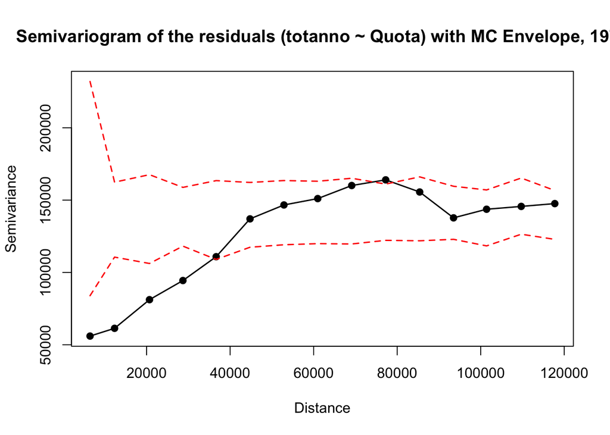

```r
data_1974$res_lm <- residuals(fit_lm)
vr <- variogram(res_lm ~ 1, locations = ~ XUTM + YUTM, data = data_1974)

set.seed(123)
nsim <- 99
cutoff_val <- max(vr$dist) * 1.0001
width_val <- cutoff_val / nrow(vr)

sim_gamma <- replicate(nsim, {
  data_1974$res_perm <- sample(data_1974$res_lm)
  vr_perm <- variogram(res_perm ~ 1, locations = ~ XUTM + YUTM, data = data_1974,
                       cutoff = cutoff_val, width = width_val)
  vr_perm$gamma[1:nrow(vr)]
})

env_low <- apply(sim_gamma, 1, min, na.rm = TRUE)
env_high <- apply(sim_gamma, 1, max, na.rm = TRUE)

plot(vr$dist, vr$gamma,
     ylim = range(c(vr$gamma, env_low, env_high), na.rm = TRUE),
     pch = 19, col = "black",
     xlab = "Distance", ylab = "Semivariance",
     main = "Semivariogram of the residuals (totanno ~ Quota) with MC Envelope, 1974")
lines(vr$dist, vr$gamma, col = "black", lwd = 1.5)
lines(vr$dist, env_low, lty = 2, col = "red", lwd = 1.5)
lines(vr$dist, env_high, lty = 2, col = "red", lwd = 1.5)
```

```r
# 1980

fit_lm <- lm(totanno ~ Quota, data = data_1980)
summary(fit_lm)
```

```
Call:
lm(formula = totanno ~ Quota, data = data_1980)

Residuals:
    Min      1Q  Median      3Q     Max
-845.16 -302.04  -60.63  245.40 1415.85

Coefficients:
             Estimate Std. Error t value Pr(>|t|)
(Intercept) 827.76758   54.32906  15.236  < 2e-16 ***
Quota         0.62581    0.09784   6.397 1.39e-09 ***
---
Signif. codes:  0 '***' 0.001 '**' 0.01 '*' 0.05 '.' 0.1 ' ' 1

Residual standard error: 437.9 on 176 degrees of freedom
Multiple R-squared:  0.1886,    Adjusted R-squared:  0.184
F-statistic: 40.92 on 1 and 176 DF,  p-value: 1.388e-09
```

```r
shapiro.test(residuals(fit_lm))
```

```
    Shapiro-Wilk normality test

data:  residuals(fit_lm)
W = 0.96147, p-value = 8.207e-05
```

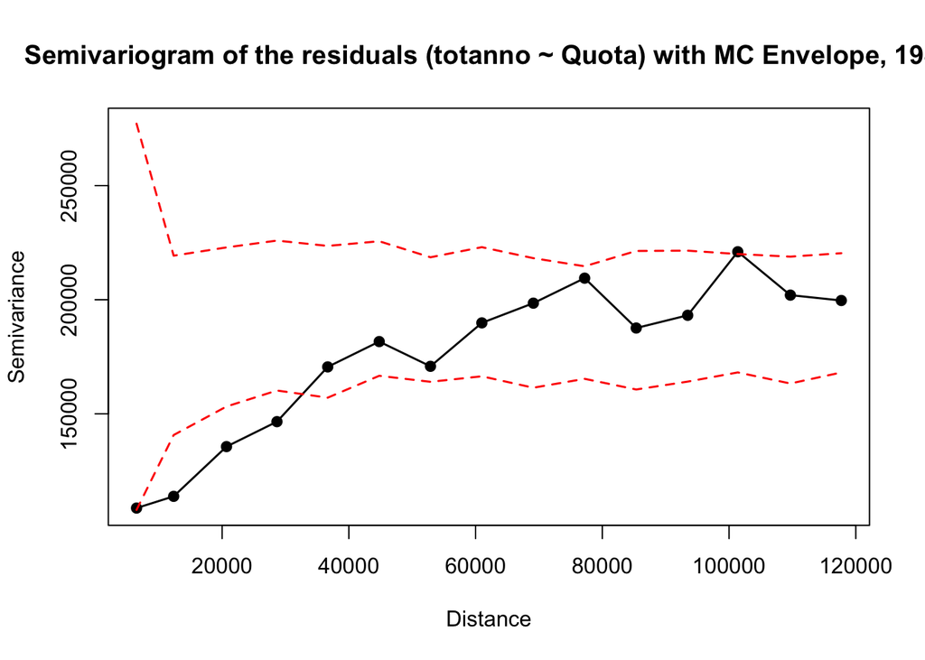

```r
data_1980$res_lm <- residuals(fit_lm)
vr <- variogram(res_lm ~ 1, locations = ~ XUTM + YUTM, data = data_1980)

set.seed(123)
nsim <- 99
cutoff_val <- max(vr$dist) * 1.0001
width_val <- cutoff_val / nrow(vr)

sim_gamma <- replicate(nsim, {
  data_1980$res_perm <- sample(data_1980$res_lm)
  vr_perm <- variogram(res_perm ~ 1, locations = ~ XUTM + YUTM, data = data_1980,
                       cutoff = cutoff_val, width = width_val)
  vr_perm$gamma[1:nrow(vr)]
})

env_low <- apply(sim_gamma, 1, min, na.rm = TRUE)
env_high <- apply(sim_gamma, 1, max, na.rm = TRUE)

plot(vr$dist, vr$gamma,
     ylim = range(c(vr$gamma, env_low, env_high), na.rm = TRUE),
     pch = 19, col = "black",
     xlab = "Distance", ylab = "Semivariance",
     main = "Semivariogram of the residuals (totanno ~ Quota) with MC Envelope, 1980")
lines(vr$dist, vr$gamma, col = "black", lwd = 1.5)
lines(vr$dist, env_low, lty = 2, col = "red", lwd = 1.5)
lines(vr$dist, env_high, lty = 2, col = "red", lwd = 1.5)
```

Evaluating the residuals of the linear regression models (totanno ~ Quota) requires a cautious diagnostic interpretation regarding both distributional normality and spatial independence. In 1973, the Shapiro–Wilk test yields a non-significant result ($W = 0.9947, p = 0.7449$); however, failing to reject the null hypothesis only indicates the absence of strong evidence against normality and does not formally confirm that the residuals follow a Gaussian distribution. Conversely, for both 1974 ($W = 0.9615, p = 5.39 \times 10^{-5}$) and 1980 ($W = 0.9615, p = 8.21 \times 10^{-5}$), the Shapiro–Wilk test strongly rejects the normality hypothesis, reflecting pronounced positive skewness and extreme positive residuals exceeding $+1400\text{ mm}$. More importantly, the Shapiro–Wilk test evaluates only the marginal distribution of the residuals and is completely blind to their geographical arrangement; therefore, even a non-significant result like that of 1973 cannot validate the standard Ordinary Least Squares (OLS) assumptions in a spatial context.

Then, over the three-year period, the empirical semivariograms of the residuals fall well below the lower bound of the Monte Carlo permutation envelope at short and medium distances: residual spatial dependence remains significant up to approximately 75 km in 1973, 37 km in 1974, and 33 km in 1980. This positive spatial autocorrelation of the residuals violates the independence assumption of ordinary least squares (OLS), which leads to an underestimation of standard errors and makes the $t$-tests and $p$-values of the classical regression artificially too optimistic.

**1.3 Map of the rainfall**

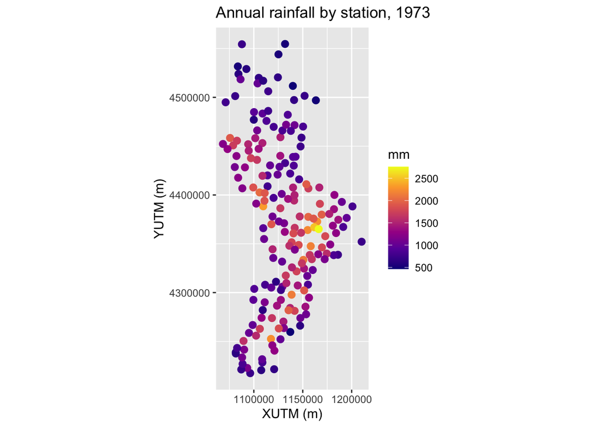

```r
# 1973

ggplot(data_1973, aes(XUTM, YUTM, colour = totanno)) +
  geom_point(size = 2.5) +
  scale_colour_viridis_c(option = "C", name = "mm") +
  coord_equal() +
  labs(x = "XUTM (m)", y = "YUTM (m)", title = "Annual rainfall by station, 1973")
```

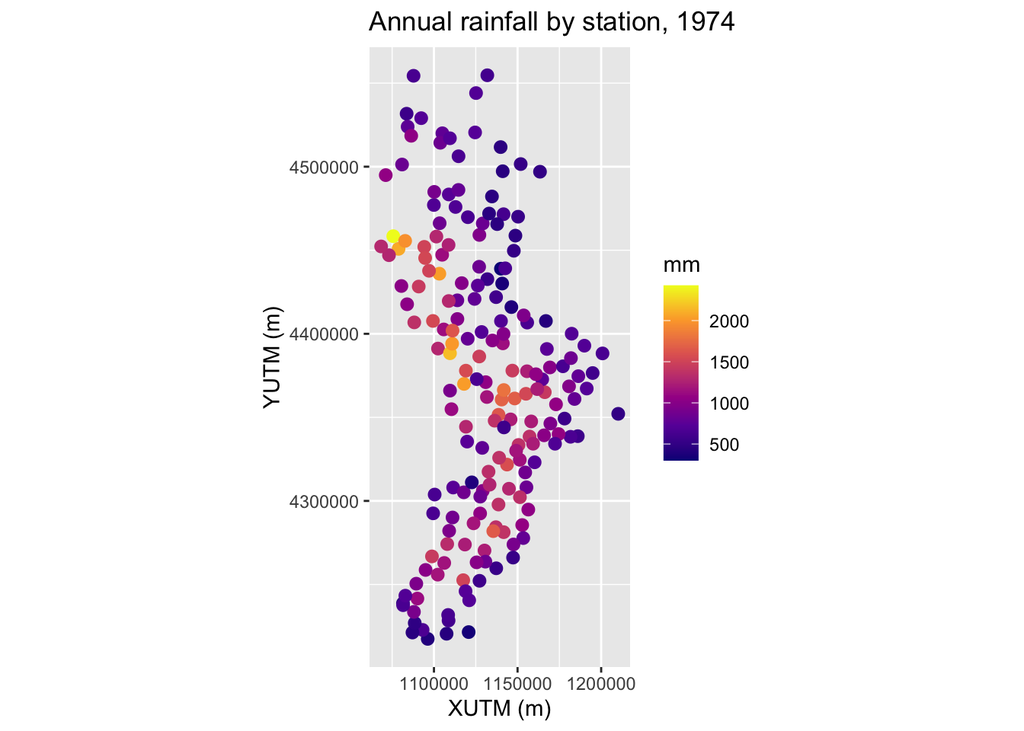

```r
# 1974

ggplot(data_1974, aes(XUTM, YUTM, colour = totanno)) +
  geom_point(size = 2.5) +
  scale_colour_viridis_c(option = "C", name = "mm") +
  coord_equal() +
  labs(x = "XUTM (m)", y = "YUTM (m)", title = "Annual rainfall by station, 1974")
```

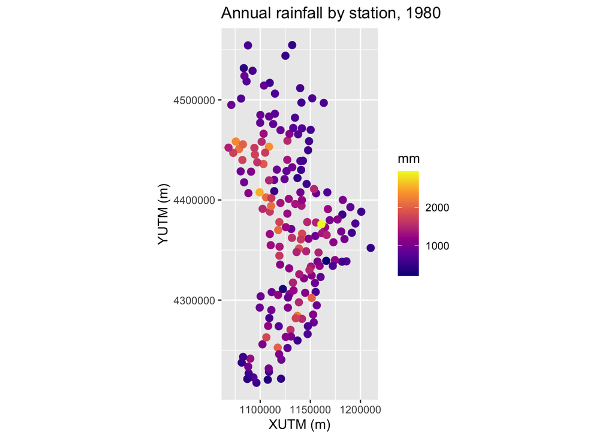

```r
# 1980

ggplot(data_1980, aes(XUTM, YUTM, colour = totanno)) +
  geom_point(size = 2.5) +
  scale_colour_viridis_c(option = "C", name = "mm") +
  coord_equal() +
  labs(x = "XUTM (m)", y = "YUTM (m)", title = "Annual rainfall by station, 1980")
```

The spatial distribution of annual rainfall across the monitoring network in 1973, 1974, and 1980 reveals a consistent geographical pattern and strong positive spatial autocorrelation. Across all three periods, the lowest precipitation levels (< 1000 mm, shown in dark purple) are systematically concentrated in the northern plains, along the eastern border, and at the southern tip, whereas the highest totals (> 1500 mm, in orange and yellow) align along the central and western mountainous ridge due to the orographic effect. Despite this structural stability, marked inter-annual variations emerge in both the intensity and location of rainfall maxima: 1973 exhibits the most widespread high-precipitation zone with a central peak exceeding 2500 mm (YUTM ≈ 4,370,000 m), whereas 1974 shows an overall drying trend where maximum values (~2000–2400 mm) retreat toward the northwestern coastal sector (YUTM ≈ 4,460,000 m). Finally, 1980 combines predominantly low-to-moderate peripheral rainfall with sharp local contrasts, featuring a wet cluster in the northwest and an isolated extreme peak approaching 3000 mm in the central massif.

# Question 2: choice of p in the IDW estimator

## Method

The power $p$ of the IDW estimator controls how fast the weight of a station decreases with the distance: with $p$ close to 0 all stations count almost the same and the prediction is close to the overall mean; with a large $p$ only the nearest stations matter and the surface follows the observations closely. For each year (1973, 1974 and 1980), we choose $p$ by leave-one-out cross-validation: each station is removed in turn and predicted from the others, and we keep the $p$ with the smallest RMSE, searching on a grid from 0.25 to 8 and refining around the minimum. The result is compared with a simple reference, the mean of the other stations.

```r
loocv_idw <- function(d, p_grid = seq(0.25, 8, by = 0.25)) {
  z  <- d$totanno; n <- length(z)
  Dm <- as.matrix(dist(cbind(d$XUTM, d$YUTM))); diag(Dm) <- Inf   # a station never predicts itself
  pred <- function(p) { W <- Dm^(-p); as.vector(W %*% z) / rowSums(W) }
  rmse <- function(p) sqrt(mean((z - pred(p))^2))
  curve <- data.frame(p = p_grid, RMSE = sapply(p_grid, rmse))
  p0  <- curve$p[which.min(curve$RMSE)]
  opt <- optimize(rmse, c(max(0.01, p0 - 0.25), p0 + 0.25))        # refinement around the minimum
  ref <- sqrt(mean((z - (sum(z) - z) / (n - 1))^2))                 # mean of the other stations
  near <- curve$p[curve$RMSE <= 1.01 * opt$objective]               # p giving an RMSE within 1 % of the best
  pr <- pred(opt$minimum)
  hi <- z > quantile(z, 0.9); lo <- z < quantile(z, 0.1)
  list(curve = curve, p_opt = opt$minimum, rmse = opt$objective, ref = ref,
       mae = mean(abs(z - pr)), n = n, p_low = min(near), p_high = max(near),
       r_small = curve$RMSE[1], r_large = curve$RMSE[nrow(curve)],
       cor = cor(z, pr), bias_hi = mean(pr[hi] - z[hi]), bias_lo = mean(pr[lo] - z[lo]),
       cv = data.frame(obs = z, pred = pr))
}

years <- c(1973, 1974, 1980)
q2 <- lapply(years, function(y) loocv_idw(subset(dati, anno == y)))
names(q2) <- years
get <- function(f) sapply(q2, `[[`, f)
```

## Results

```r
q2_tab <- data.frame(
  Year = years,
  Stations = get("n"),
  `Optimal p` = round(get("p_opt"), 2),
  `p within 1 % of the best RMSE` = sapply(q2, function(r) paste0(r$p_low, " - ", r$p_high)),
  RMSE = round(get("rmse")),
  MAE = round(get("mae")),
  `RMSE of the reference` = round(get("ref")),
  `MSE reduction (%)` = round(100 * (1 - get("rmse")^2 / get("ref")^2)),
  check.names = FALSE)
knitr::kable(q2_tab, row.names = FALSE)
```

| Year | Stations | Optimal p | p within 1 % of the best RMSE | RMSE | MAE | RMSE of the reference | MSE reduction (%) |
| --- | --- | --- | --- | --- | --- | --- | --- |
| 1973 | 188 | 3.13 | 2.75 - 3.75 | 309 | 243 | 465 | 56 |
| 1974 | 187 | 3.45 | 3 - 4.25 | 255 | 198 | 408 | 61 |
| 1980 | 178 | 2.62 | 2.25 - 3 | 358 | 267 | 486 | 46 |

The table gives, for each year, the number of stations, the optimal $p$, the range of $p$ whose RMSE is less than 1 % above the best one, the cross-validation RMSE and MAE (in mm), the RMSE of the reference and the reduction of the mean squared error obtained with the IDW compared with the reference. The optimal $p$ is 3.13 in 1973, 3.45 in 1974 and 2.62 in 1980. In each year the IDW predicts clearly better than the reference: the RMSE goes from 465, 408 and 486 mm to 309, 255 and 358 mm, which is a reduction of the mean squared error of 46 to 61 %.

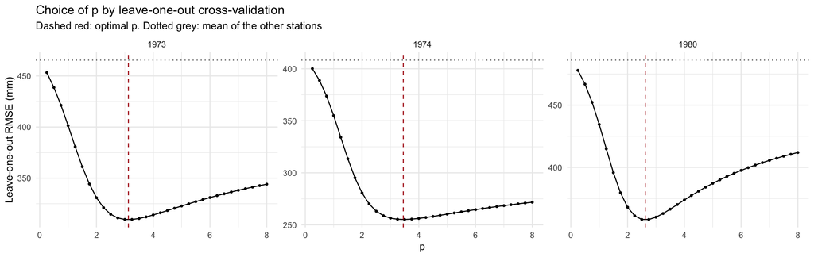

```r
curves <- do.call(rbind, lapply(years, function(y) cbind(q2[[as.character(y)]]$curve, Year = y)))
marks  <- data.frame(Year = years, p_opt = get("p_opt"), ref = get("ref"))
ggplot(curves, aes(p, RMSE)) +
  geom_line() + geom_point(size = 0.8) +
  geom_vline(data = marks, aes(xintercept = p_opt), colour = "firebrick", linetype = 2) +
  geom_hline(data = marks, aes(yintercept = ref), colour = "grey40", linetype = 3) +
  facet_wrap(~ Year, nrow = 1, scales = "free_y") +
  labs(x = "p", y = "Leave-one-out RMSE (mm)",
       title = "Choice of p by leave-one-out cross-validation",
       subtitle = "Dashed red: optimal p. Dotted grey: mean of the other stations") +
  theme_minimal()
```

*Figure 1: leave-one-out RMSE as a function of p, one panel per year (each panel has its own vertical scale). The dashed red line is the optimal p and the dotted grey line is the RMSE of the reference.*

**Comment on Figure 1.** In each year the RMSE reaches a clear minimum, at $p$ = 3.13, 3.45 and 2.62. The curve is flat around it: the values of $p$ within 1 % of the best RMSE form an interval about 1 unit wide (see the table), so the choice of $p$ is not critical.

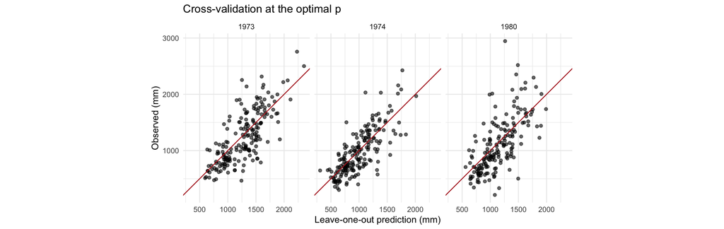

```r
cvs <- do.call(rbind, lapply(years, function(y) cbind(q2[[as.character(y)]]$cv, Year = y)))
ggplot(cvs, aes(pred, obs)) +
  geom_point(alpha = 0.6) + geom_abline(colour = "firebrick") +
  facet_wrap(~ Year, nrow = 1) + coord_equal() +
  labs(x = "Leave-one-out prediction (mm)", y = "Observed (mm)",
       title = "Cross-validation at the optimal p") +
  theme_minimal()
```

*Figure 2: observed rainfall against the leave-one-out prediction at the optimal p. The red line is the line prediction = observation.*

**Comment on Figure 2.** The points are spread around the red line, with a correlation between observation and prediction of 0.75 in 1973, 0.78 in 1974 and 0.68 in 1980. The wettest stations (top 10 % of the observed values) are under-predicted, by 417, 348 and 601 mm on average, and the driest ones (bottom 10 %) are over-predicted, by 251, 224 and 410 mm.

The optimal values of $p$ are used in the next question to map the rainfall on the prediction grid.

# Question 3: interpolation and map

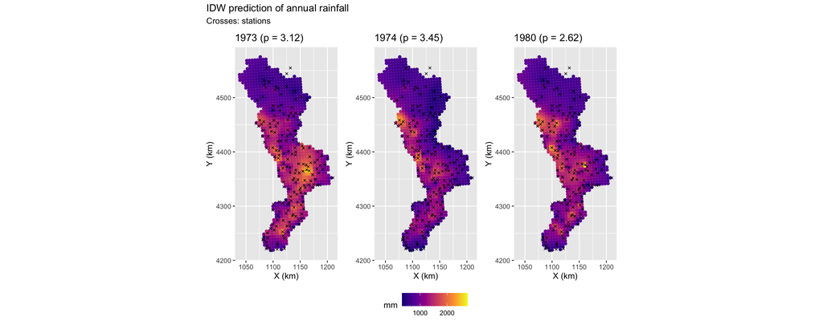

```r
library(patchwork)

interpolation_map <- function(data, p_opt, grid, year, limits = NULL) {
  fct_grid <- grid
  fct_grid$pred <- idw(totanno ~ 1, locations = ~ XUTM + YUTM, data = data,
                       newdata = grid, idp = p_opt, debug.level = 0)$var1.pred

  ggplot() +
    geom_point(data = fct_grid, aes(XUTM / 1000, YUTM / 1000, colour = pred), size = 1.5) +
    geom_point(data = data, aes(XUTM / 1000, YUTM / 1000), shape = 4, size = 1) +
    scale_colour_viridis_c(option = "C", name = "mm", limits = limits) +
    coord_equal() +
    labs(x = "X (km)", y = "Y (km)",
         title = paste0(year, " (p = ", round(p_opt, 2), ")")) +
    theme(legend.position = "bottom")
}

params <- list(c(1973, 3.125), c(1974, 3.45), c(1980, 2.62))

all_pred <- unlist(lapply(params, function(x) {
  idw(totanno ~ 1, locations = ~ XUTM + YUTM,
      data = subset(dati, anno == x[1]),
      newdata = grid, idp = x[2], debug.level = 0)$var1.pred
}))
lims <- range(all_pred, na.rm = TRUE)

interpolation_map(subset(dati, anno == 1973), 3.125, grid, 1973, lims) +
interpolation_map(subset(dati, anno == 1974), 3.45,  grid, 1974, lims) +
interpolation_map(subset(dati, anno == 1980), 2.62,  grid, 1980, lims) +
  plot_layout(guides = "collect") +
  plot_annotation(title = "IDW prediction of annual rainfall",
                  subtitle = "Crosses: stations") &
  theme(legend.position = "bottom")
```